rigrag is an R package for identifying genes preferentially targeted or avoided for integration during HIV-1 infection. The integration frequency into each gene is compared to the expected integration frequency according to phenomenological models of random integration. Genes with integration frequencies higher than random are called upper outliers or recurrent integration genes (RIGs) and genes with integration frequencies lower than random are called lower outliers or recurrent avoided genes (RAGs). Genes with integration frequencies indistinguishable from random are called non-outliers. The package includes functions to easily import genic integration site bed files *en masse*, to easily generate matched random models of HIV-1 integration, to classify genes into their respective outlier category, to easily and reproducibly generate plots of the data, and an assortment of other functions useful for comparing samples to each other. rigrag is described in more detail in a manuscript currently under review.

### Example files

Example files suitable for use with rigrag are provided on [GitHub](https://github.com/gbedwell/example_files).

These files include:

- The gene annotation file used to match total integration sites to genes.
- An example bash script for performing the intersection with BEDtools in a way that will output a file suitable for import into rigrag.
- 2 total integration site bed files from HEK293T cells.
- 2 genic integration site bed files in a rigrag-compatible format derived from the total bed files and the gene annotation file.

The following examples were created using these genic integration site bed files.

### Installation

```r
devtools::install_github("gbedwell/rigrag")
```

### Import genic integration site coordinates

#### Define the file-specific parameters

1. Generate a list of file names to be imported.
2. Define a list of sample identifiers for each file. These must be listed in the same order as the file names.

```r
files <- generate_file_list(
   directory="~/Documents/github/example_files/rigrag_files/example_bed/",
   pattern="*genic.bed")

sample.ids <- list("Sample #1", "Sample #2")
```

#### Import the listed files

The flag `collpased = TRUE` counts the number of integration sites in each gene in each sample and returns a collapsed data frame containing all unique genes, the number of integration events per gene, and the fraction of genic integration in each gene. To simply view all integration sites, set the flag to `FALSE`. rigrag is designed to operate on the collapsed form of the data (seen below).

```r
sample.df <- int_file_import(files=files, sample.ids=sample.ids, collapsed = TRUE)
```

gene.name

gene.start

gene.end

gene.strand

total.sites

sample

genic.sites

int.counts

frac.int

gene.length

PPP1R9A

94536513

94925727

22771

Sample #1

19518

5

0.0002562

389214

GMPS

155588324

155661815

22771

Sample #1

19518

2

0.0001025

73491

PCDH15

55562530

57387702

22771

Sample #1

19518

11

0.0005636

1825172

WDR26

224572844

224624735

22771

Sample #1

19518

11

0.0005636

51891

ZNF652

47366567

47439835

22771

Sample #1

19518

3

0.0001537

73268

RABEP1

5185557

5289129

22771

Sample #1

19518

43

0.0022031

103572

Please ignore the bullet points in the table. This is a result of pandoc interpreting “+” and “-” as list elements when rendering this HTML file.

### Calculate the random model parameters according to the matched fragmentation method.

The models of random integration used in the rigrag pipeline are phenomenological models derived from large datasets of theoretical random integration site generated *in silico*. These datasets were generated by randomly fragmenting the human genome according to either random fragmentation (e.g. acoustic shearing) or pattern fragmentation (e.g. restriction enzyme digestion). The two restriction enzyme cocktails used, MseI/BglII and NheI/AvrII/SpeI/BamHI, were chosen to match previously published integration site datasets. To generate the appropriate model, the user must define which fragmentation method to use. For random fragmentation, use the function `random_frag_model()`. For enzyme digestion, use the function `pattern_frag_model()` and define the particular cocktail with the flag `pattern=“MB”` or `pattern=“NASB”`.

```r
models.df <- pattern_frag_model(df=sample.df, pattern="MB")
```

The output contains the same information as the input data frame, but with additional columns. The first three additional columns denote the expected fraction of genic integration (expected.frac), the expected upper limit of integration frequency (upper.limit), and the expected lower limit of integration frequency (lower.limit) for an equally sized random dataset. The last additional column states whether or not a given gene scores as an upper, lower, or non-outlier in the each sample (outlier.type).

Examples of these four new columns are printed below:

| gene.name | expected.frac | upper.limit | lower.limit | outlier.type |
| --- | --- | --- | --- | --- |
| AC002395.1 | 0.0000026 | 0.0002512 | 0 | NONE |
| ACOX1 | 0.0000292 | 0.0003756 | 0 | UPPER |
| ARHGAP24 | 0.0003741 | 0.0009184 | 0 | NONE |
| ARID4B | 0.0001410 | 0.0005864 | 0 | UPPER |
| BTN3A2 | 0.0000118 | 0.0003212 | 0 | NONE |
| C18orf25 | 0.0000683 | 0.0004609 | 0 | NONE |

### Output model plots

The `model_plot()` function in rigrag is intended to quickly output a visualization of the data contained within the `*_frag_model()` output. The generated plots depict 4 important things:

1. The calculated random model. This is depicted as the gray shaded region. The expected integration frequency is shown as the straight line near the middle of the shaded region. The upper and lower boundaries of the model are depicted above and below the expected integration frequency, respectively.
2. Upper outliers (RIGs). These are depicted as blue data points. These represent the genes integrated into *more* frequently than expected.
3. Lower outliers (RAGs). These are depicted as red data points. These represent the genes integration into *less* frequently than expected
4. Non-outliers. These are depicted as gray data points. These represent genes integrated into at frequencies indistinguishable from random.

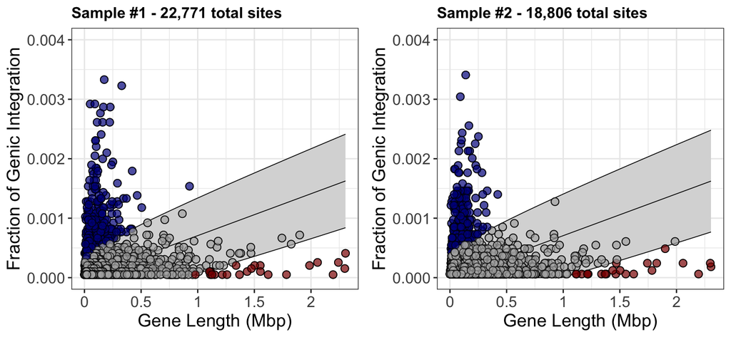

```r
model_plot(df=models.df,
           output.type="combo",
           num.col=2,
           labels="",
           label.size=17,
           write.out = "no")
```

### Additional information

The functions described above represent the core of rigrag. The package does, however, contain other functions that facilitate the easy comparison of RIGs/RAGs called between samples. For information on these functions or for comments/questions about rigrag in general please feel free to contact me directly.